# Insights from University Rankings Data

# Data Loading and Cleaning

```r
data_path <- '../data/cwurData.csv'
university_data <- read_csv(data_path)
# Print all column names for reference
cat("\nColumn names in dataset:\n")
```

```
##
## Column names in dataset:
```

```r
print(names(university_data))
```

```
##  [1] "world_rank"           "institution"          "country"
##  [4] "national_rank"        "quality_of_education" "alumni_employment"
##  [7] "quality_of_faculty"   "publications"         "influence"
## [10] "citations"            "broad_impact"         "patents"
## [13] "score"                "year"
```

```r
# Remove rows with missing values
clean_data <- na.omit(university_data)
# Ensure 'world_rank' is numeric
if ("world_rank" %in% names(clean_data) && !is.numeric(clean_data$world_rank)) {
  clean_data$world_rank <- as.numeric(clean_data$world_rank)
}
```

## Preview of Raw Dataset (Before Cleaning)

```r
# Show the first few rows and column names of the raw dataset before cleaning
head(university_data)
```

| world_rank | institution | country | national_rank | quality_of_education | alumni_employment | quality_of_faculty | publications | influence | citations | broad_impact | patents | score | year |
| --- | --- | --- | --- | --- | --- | --- | --- | --- | --- | --- | --- | --- | --- |
| 1 | Harvard University | USA | 1 | 7 | 9 | 1 | 1 | 1 | 1 | NA | 5 | 100.00 | 2012 |
| 2 | Massachusetts Institute of Technology | USA | 2 | 9 | 17 | 3 | 12 | 4 | 4 | NA | 1 | 91.67 | 2012 |
| 3 | Stanford University | USA | 3 | 17 | 11 | 5 | 4 | 2 | 2 | NA | 15 | 89.50 | 2012 |
| 4 | University of Cambridge | United Kingdom | 1 | 10 | 24 | 4 | 16 | 16 | 11 | NA | 50 | 86.17 | 2012 |
| 5 | California Institute of Technology | USA | 4 | 2 | 29 | 7 | 37 | 22 | 22 | NA | 18 | 85.21 | 2012 |
| 6 | Princeton University | USA | 5 | 8 | 14 | 2 | 53 | 33 | 26 | NA | 101 | 82.50 | 2012 |

```r
str(university_data)
```

```
## spc_tbl_ [2,200 × 14] (S3: spec_tbl_df/tbl_df/tbl/data.frame)
##  $ world_rank          : num [1:2200] 1 2 3 4 5 6 7 8 9 10 ...
##  $ institution         : chr [1:2200] "Harvard University" "Massachusetts Institute of Technology" "Stanford University" "University of Cambridge" ...
##  $ country             : chr [1:2200] "USA" "USA" "USA" "United Kingdom" ...
##  $ national_rank       : num [1:2200] 1 2 3 1 4 5 2 6 7 8 ...
##  $ quality_of_education: num [1:2200] 7 9 17 10 2 8 13 14 23 16 ...
##  $ alumni_employment   : num [1:2200] 9 17 11 24 29 14 28 31 21 52 ...
##  $ quality_of_faculty  : num [1:2200] 1 3 5 4 7 2 9 12 10 6 ...
##  $ publications        : num [1:2200] 1 12 4 16 37 53 15 14 13 6 ...
##  $ influence           : num [1:2200] 1 4 2 16 22 33 13 6 12 5 ...
##  $ citations           : num [1:2200] 1 4 2 11 22 26 19 15 14 3 ...
##  $ broad_impact        : num [1:2200] NA NA NA NA NA NA NA NA NA NA ...
##  $ patents             : num [1:2200] 5 1 15 50 18 101 26 66 5 16 ...
##  $ score               : num [1:2200] 100 91.7 89.5 86.2 85.2 ...
##  $ year                : num [1:2200] 2012 2012 2012 2012 2012 ...
##  - attr(*, "spec")=
##   .. cols(
##   ..   world_rank = col_double(),
##   ..   institution = col_character(),
##   ..   country = col_character(),
##   ..   national_rank = col_double(),
##   ..   quality_of_education = col_double(),
##   ..   alumni_employment = col_double(),
##   ..   quality_of_faculty = col_double(),
##   ..   publications = col_double(),
##   ..   influence = col_double(),
##   ..   citations = col_double(),
##   ..   broad_impact = col_double(),
##   ..   patents = col_double(),
##   ..   score = col_double(),
##   ..   year = col_double()
##   .. )
##  - attr(*, "problems")=<externalptr>
```

# Data Exploration

Below, we explore the structure and main features of the cleaned dataset. This helps us understand the data before diving into the research questions.

```r
# Structure and summary
str(clean_data)
```

```
## tibble [2,000 × 14] (S3: tbl_df/tbl/data.frame)
##  $ world_rank          : num [1:2000] 1 2 3 4 5 6 7 8 9 10 ...
##  $ institution         : chr [1:2000] "Harvard University" "Stanford University" "Massachusetts Institute of Technology" "University of Cambridge" ...
##  $ country             : chr [1:2000] "USA" "USA" "USA" "United Kingdom" ...
##  $ national_rank       : num [1:2000] 1 2 3 1 2 4 5 6 7 8 ...
##  $ quality_of_education: num [1:2000] 1 11 3 2 7 13 4 10 5 9 ...
##  $ alumni_employment   : num [1:2000] 1 2 11 10 12 8 22 14 16 25 ...
##  $ quality_of_faculty  : num [1:2000] 1 4 2 5 10 9 6 8 3 11 ...
##  $ publications        : num [1:2000] 1 5 15 10 11 14 7 17 70 18 ...
##  $ influence           : num [1:2000] 1 3 2 9 12 13 4 19 25 7 ...
##  $ citations           : num [1:2000] 1 3 2 12 11 9 3 10 19 32 ...
##  $ broad_impact        : num [1:2000] 1 4 2 13 12 13 7 18 41 19 ...
##  $ patents             : num [1:2000] 2 6 1 48 16 4 28 149 204 45 ...
##  $ score               : num [1:2000] 100 99.1 98.7 97.6 97.5 ...
##  $ year                : num [1:2000] 2014 2014 2014 2014 2014 ...
##  - attr(*, "na.action")= 'omit' Named int [1:200] 1 2 3 4 5 6 7 8 9 10 ...
##   ..- attr(*, "names")= chr [1:200] "1" "2" "3" "4" ...
```

```r
summary(clean_data)
```

```
##    world_rank     institution          country          national_rank
##  Min.   :   1.0   Length:2000        Length:2000        Min.   :  1.00
##  1st Qu.: 250.8   Class :character   Class :character   1st Qu.:  7.00
##  Median : 500.5   Mode  :character   Mode  :character   Median : 22.00
##  Mean   : 500.5                                         Mean   : 42.52
##  3rd Qu.: 750.2                                         3rd Qu.: 52.00
##  Max.   :1000.0                                         Max.   :229.00
##  quality_of_education alumni_employment quality_of_faculty  publications
##  Min.   :  1.0        Min.   :  1.0     Min.   :  1.0      Min.   :   1.0
##  1st Qu.:250.8        1st Qu.:250.8     1st Qu.:210.0      1st Qu.: 250.8
##  Median :355.0        Median :478.0     Median :210.0      Median : 500.5
##  Mean   :296.0        Mean   :385.3     Mean   :191.1      Mean   : 500.4
##  3rd Qu.:367.0        3rd Qu.:500.2     3rd Qu.:218.0      3rd Qu.: 750.0
##  Max.   :367.0        Max.   :567.0     Max.   :218.0      Max.   :1000.0
##    influence       citations      broad_impact       patents
##  Min.   :  1.0   Min.   :  1.0   Min.   :   1.0   Min.   :  1.0
##  1st Qu.:250.8   1st Qu.:234.0   1st Qu.: 250.5   1st Qu.:242.8
##  Median :500.5   Median :428.0   Median : 496.0   Median :481.0
##  Mean   :500.2   Mean   :449.3   Mean   : 496.7   Mean   :470.3
##  3rd Qu.:750.2   3rd Qu.:645.0   3rd Qu.: 741.0   3rd Qu.:737.0
##  Max.   :991.0   Max.   :812.0   Max.   :1000.0   Max.   :871.0
##      score             year
##  Min.   : 44.02   Min.   :2014
##  1st Qu.: 44.44   1st Qu.:2014
##  Median : 44.96   Median :2014
##  Mean   : 47.07   Mean   :2014
##  3rd Qu.: 46.81   3rd Qu.:2015
##  Max.   :100.00   Max.   :2015
```

```r
cat("\nMissing values per column:\n")
```

```
##
## Missing values per column:
```

```r
print(colSums(is.na(clean_data)))
```

```
##           world_rank          institution              country
##                    0                    0                    0
##        national_rank quality_of_education    alumni_employment
##                    0                    0                    0
##   quality_of_faculty         publications            influence
##                    0                    0                    0
##            citations         broad_impact              patents
##                    0                    0                    0
##                score                 year
##                    0                    0
```

```r
cat("\nNumber of unique values per column:\n")
```

```
##
## Number of unique values per column:
```

```r
print(sapply(clean_data, function(x) length(unique(x))))
```

```
##           world_rank          institution              country
##                 1000                 1023                   59
##        national_rank quality_of_education    alumni_employment
##                  229                  367                  565
##   quality_of_faculty         publications            influence
##                  199                  987                  944
##            citations         broad_impact              patents
##                  100                  343                  738
##                score                 year
##                  646                    2
```

## Visualizations for EDA

Let’s visualize the distribution of key variables and relationships between them.

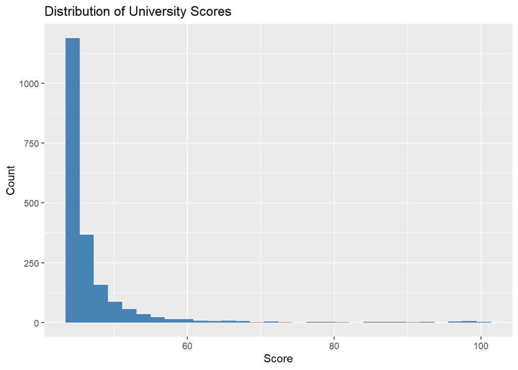

```r
# Histogram of university scores
ggplot(clean_data, aes(x = score)) +
  geom_histogram(fill = 'steelblue', bins = 30) +
  labs(title = "Distribution of University Scores", x = "Score", y = "Count")
```

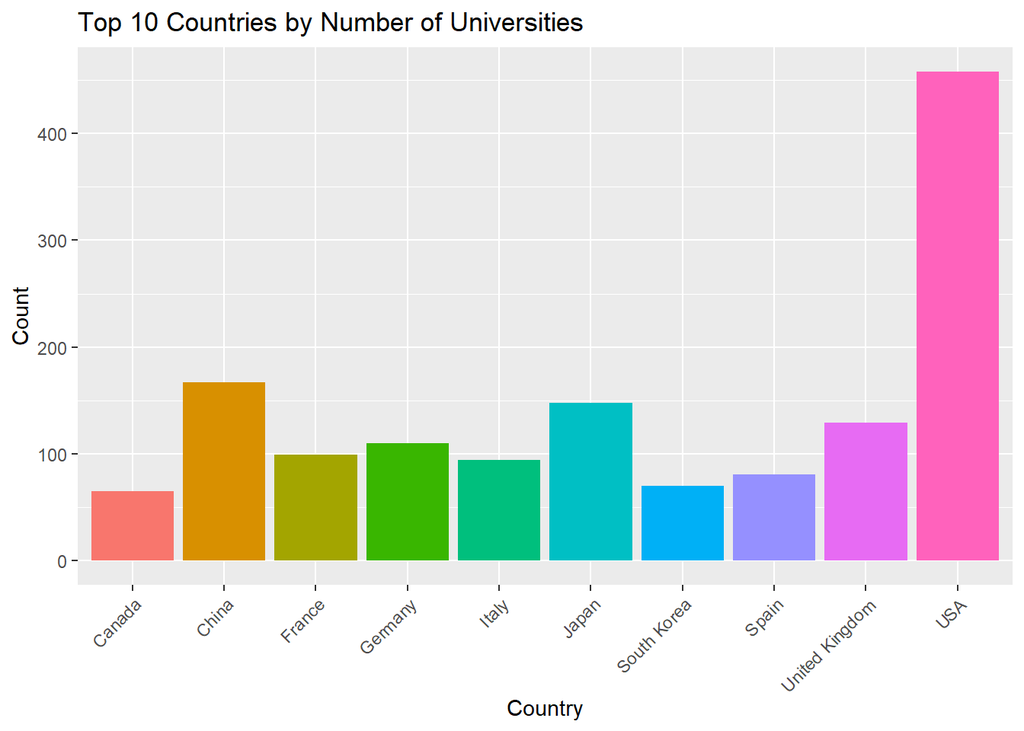

```r
# Barplot of top 10 countries by university count
top_countries <- clean_data %>% count(country, sort = TRUE) %>% top_n(10, n) %>% pull(country)
ggplot(filter(clean_data, country %in% top_countries), aes(x = country, fill = country)) +
  geom_bar() +
  labs(title = "Top 10 Countries by Number of Universities", x = "Country", y = "Count") +
  theme(axis.text.x = element_text(angle = 45, hjust = 1), legend.position = "none")
```

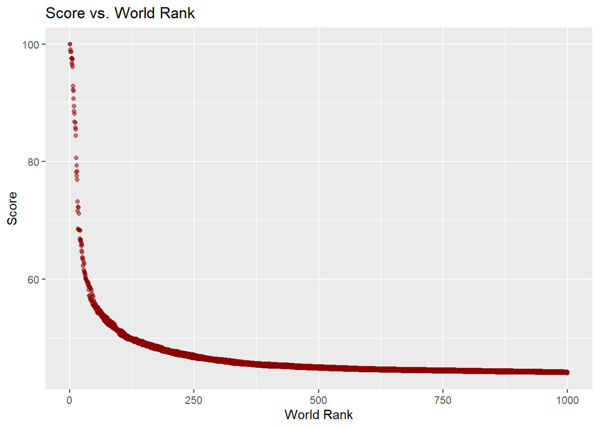

```r
# Scatterplot: Score vs. World Rank
ggplot(clean_data, aes(x = world_rank, y = score)) +
  geom_point(alpha = 0.5, color = 'darkred') +
  labs(title = "Score vs. World Rank", x = "World Rank", y = "Score")
```

These visualizations provide an overview of the data distribution, the most represented countries, and the relationship between world rank and score.

# Research Question 1

## Which Countries Have the Best University Scores?

We show the average university score for the top 5 countries with the most universities. This highlights which countries tend to have higher scores overall.

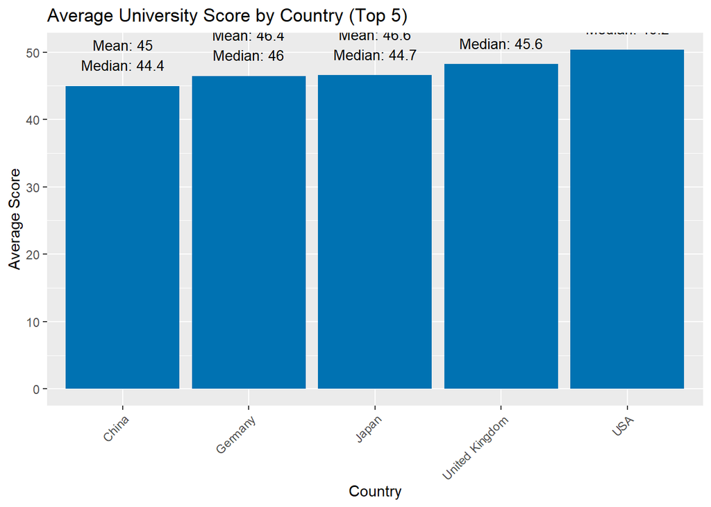

```r
top5 <- clean_data %>% count(country, sort = TRUE) %>% top_n(5, n) %>% pull(country)
country_stats <- clean_data %>% filter(country %in% top5) %>% group_by(country) %>% summarise(mean_score = mean(score, na.rm = TRUE), median_score = median(score, na.rm = TRUE), n = n())
ggplot(country_stats, aes(x = reorder(country, mean_score), y = mean_score, fill = country)) +
  geom_bar(stat = "identity", fill = "#0072B2") +
  geom_text(aes(label = paste0("Mean: ", round(mean_score, 1), "\nMedian: ", round(median_score, 1))), vjust = -0.5, size = 3.5) +
  labs(title = "Average University Score by Country (Top 5)", x = "Country", y = "Average Score") +
  theme(axis.text.x = element_text(angle = 45, hjust = 1), legend.position = "none")
```

**Explanation:** This barplot compares the average and median scores of universities in the top 5 countries by count. The text labels above each bar show both the mean and median, making it easy to see which countries have the highest and most consistent scores. More universities in a country may indicate a stronger higher education system overall.

# Research Question 2

## What Most Impacts a University’s Global Ranking?

We use a scatterplot with a trend line to show how the number of publications relates to world rank (lower rank means better university).

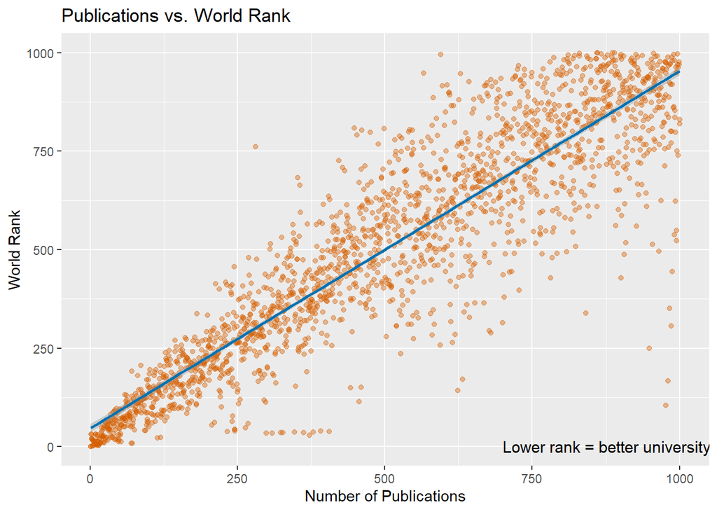

```r
if (all(c("publications", "world_rank") %in% names(clean_data))) {
ggplot(clean_data, aes(x = publications, y = world_rank)) +
    geom_point(alpha = 0.4, color = "#D55E00") +
    geom_smooth(method = "lm", color = "#0072B2") +
    labs(title = "Publications vs. World Rank", x = "Number of Publications", y = "World Rank") +
    annotate("text", x = max(clean_data$publications, na.rm = TRUE)*0.7, y = min(clean_data$world_rank, na.rm = TRUE), label = "Lower rank = better university", color = "black", size = 4, hjust = 0)
} else {
  cat("\nColumns for Q2 not found. Please check column names above and update the code accordingly.\n")
}
```

```r
# Linear regression summary for Publications vs. World Rank
if (all(c("publications", "world_rank") %in% names(clean_data))) {
  lm_q2 <- lm(world_rank ~ publications, data = clean_data)
  summary(lm_q2)
}
```

```
##
## Call:
## lm(formula = world_rank ~ publications, data = clean_data)
##
## Residuals:
##     Min      1Q  Median      3Q     Max
## -828.65  -55.34   -0.13   64.87  459.46
##
## Coefficients:
##               Estimate Std. Error t value Pr(>|t|)
## (Intercept)  46.742637   5.456834   8.566   <2e-16 ***
## publications  0.906762   0.009446  95.992   <2e-16 ***
## ---
## Signif. codes:  0 '***' 0.001 '**' 0.01 '*' 0.05 '.' 0.1 ' ' 1
##
## Residual standard error: 121.9 on 1998 degrees of freedom
## Multiple R-squared:  0.8218, Adjusted R-squared:  0.8217
## F-statistic:  9214 on 1 and 1998 DF,  p-value: < 2.2e-16
```

# Research Question 3

## How Do University Scores Vary Within the Top 5 Countries?

We show boxplots for the top 5 countries with the most universities to make the comparison easier.

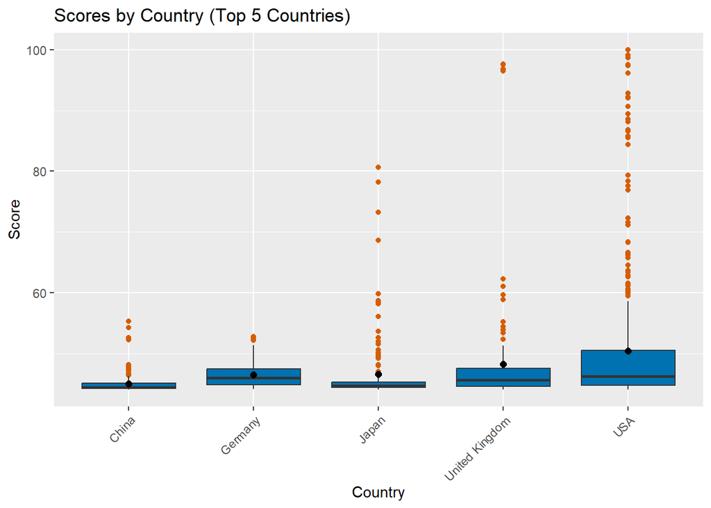

```r
top_countries <- clean_data %>% count(country, sort = TRUE) %>% top_n(5, n) %>% pull(country)
ggplot(filter(clean_data, country %in% top_countries),
       aes(x = country, y = score, fill = country)) +
  geom_boxplot(outlier.color = "#D55E00", outlier.shape = 16, fill = "#0072B2") +
  stat_summary(fun = mean, geom = "point", shape = 20, size = 3, color = "black", fill = "black") +
  labs(title = "Scores by Country (Top 5 Countries)", x = "Country", y = "Score") +
  theme(axis.text.x = element_text(angle = 45, hjust = 1), legend.position = "none")
```

```r
# ANOVA: Do mean scores differ significantly between top 5 countries?
if (all(c("country", "score") %in% names(clean_data))) {
  top_countries <- clean_data %>% count(country, sort = TRUE) %>% top_n(5, n) %>% pull(country)
  anova_data <- filter(clean_data, country %in% top_countries)
  anova_q3 <- aov(score ~ country, data = anova_data)
  summary(anova_q3)
}
```

```
##               Df Sum Sq Mean Sq F value   Pr(>F)
## country        4   4618  1154.5   16.43 4.73e-13 ***
## Residuals   1007  70743    70.3
## ---
## Signif. codes:  0 '***' 0.001 '**' 0.01 '*' 0.05 '.' 0.1 ' ' 1
```

**Explanation:** These boxplots show the spread, median, and mean (black dot) of university scores for the top 5 countries. Outliers are highlighted in orange. This makes it easy to compare which countries have higher or more consistent scores, and spot any unusual values.

- Some countries have a wider spread, indicating more variation in university scores.
- Outliers (orange) highlight universities that differ greatly from the norm.

# Research Question 4

## What Are the Strongest Predictors of a University’s World Rank?

We use a correlation plot to identify which numeric variables are most strongly related to world rank.

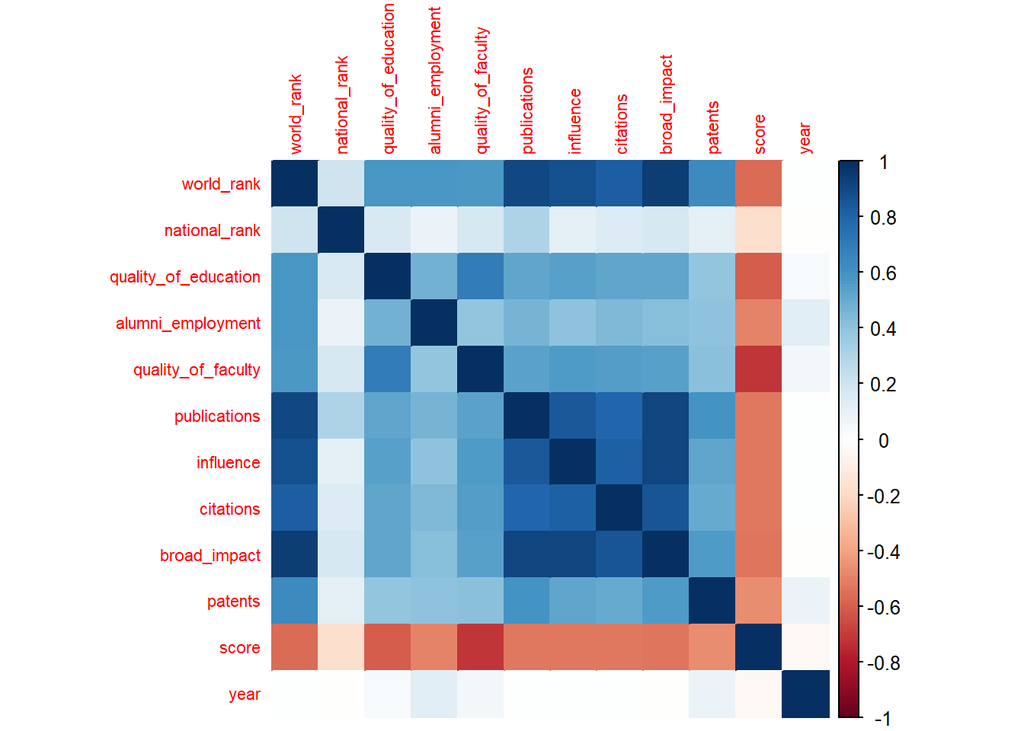

```r
if (!requireNamespace("corrplot", quietly = TRUE)) install.packages("corrplot")
library(corrplot)
num_cols <- sapply(clean_data, is.numeric)
if (sum(num_cols) > 1) {
  cor_matrix <- cor(clean_data[, num_cols], use = "complete.obs")
  corrplot(cor_matrix, method = "color", tl.cex = 0.7)
}
```

```r
# Multiple regression: Predicting world rank from key features
if (all(c("world_rank", "publications", "alumni_employment", "score", "patents") %in% names(clean_data))) {
  lm_q4 <- lm(world_rank ~ publications + alumni_employment + score + patents, data = clean_data)
  summary(lm_q4)
}
```

```
##
## Call:
## lm(formula = world_rank ~ publications + alumni_employment +
##     score + patents, data = clean_data)
##
## Residuals:
##     Min      1Q  Median      3Q     Max
## -678.44  -59.04    7.14   60.80  375.39
##
## Coefficients:
##                   Estimate Std. Error t value Pr(>|t|)
## (Intercept)       26.03902   26.79987   0.972   0.3314
## publications       0.74845    0.01131  66.205   <2e-16 ***
## alumni_employment  0.30775    0.01682  18.300   <2e-16 ***
## score             -1.42860    0.45932  -3.110   0.0019 **
## patents            0.10334    0.01189   8.691   <2e-16 ***
## ---
## Signif. codes:  0 '***' 0.001 '**' 0.01 '*' 0.05 '.' 0.1 ' ' 1
##
## Residual standard error: 107.1 on 1995 degrees of freedom
## Multiple R-squared:  0.8626, Adjusted R-squared:  0.8623
## F-statistic:  3131 on 4 and 1995 DF,  p-value: < 2.2e-16
```

# Research Question 5

## Does Alumni Employment Lead to Higher University Scores and Rankings?

We explore whether universities with higher alumni employment scores also have higher overall scores and better ranks.

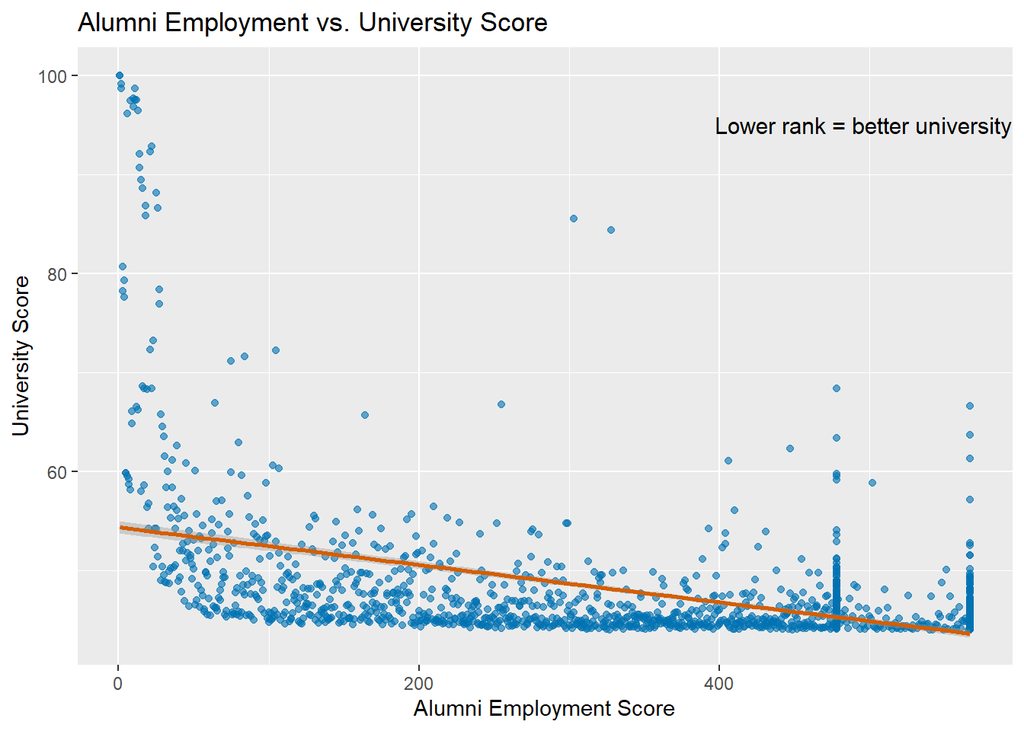

```r
if (all(c("alumni_employment", "score", "world_rank") %in% names(clean_data))) {
ggplot(clean_data, aes(x = alumni_employment, y = score, color = world_rank)) +
    geom_point(alpha = 0.6, color = "#0072B2") +
    geom_smooth(method = "lm", color = "#D55E00") +
    labs(title = "Alumni Employment vs. University Score", x = "Alumni Employment Score", y = "University Score", color = "World Rank") +
    scale_color_viridis_c() +
    annotate("text", x = max(clean_data$alumni_employment, na.rm = TRUE)*0.7, y = max(clean_data$score, na.rm = TRUE)*0.95, label = "Lower rank = better university", color = "black", size = 4, hjust = 0)
}
```

# Summary and Conclusions

## Advanced Visualizations & Categorical Analysis

### Categorical vs. Numerical Analysis: Ranking Brackets

```r
# Create ranking brackets and compare scores
if (all(c("world_rank", "score") %in% names(clean_data))) {
  clean_data$rank_bracket <- cut(clean_data$world_rank, breaks = c(0, 100, 200, 500, 1000, Inf),
                                 labels = c("Top 100", "101-200", "201-500", "501-1000", ">1000"))
  ggplot(clean_data, aes(x = rank_bracket, y = score, fill = rank_bracket)) +
    geom_boxplot() +
    labs(title = "Score Distribution by World Rank Bracket", x = "World Rank Bracket", y = "Score") +
    scale_fill_viridis_d() +
    theme_minimal()
  # ANOVA for group means
  anova_bracket <- aov(score ~ rank_bracket, data = clean_data)
  summary(anova_bracket)
}
```

[output not shown]

```
##                Df Sum Sq Mean Sq F value Pr(>F)
## rank_bracket    3  50603   16868   929.5 <2e-16 ***
## Residuals    1996  36222      18
## ---
## Signif. codes:  0 '***' 0.001 '**' 0.01 '*' 0.05 '.' 0.1 ' ' 1
```

### Heatmap: Country vs. Top 100 University Count

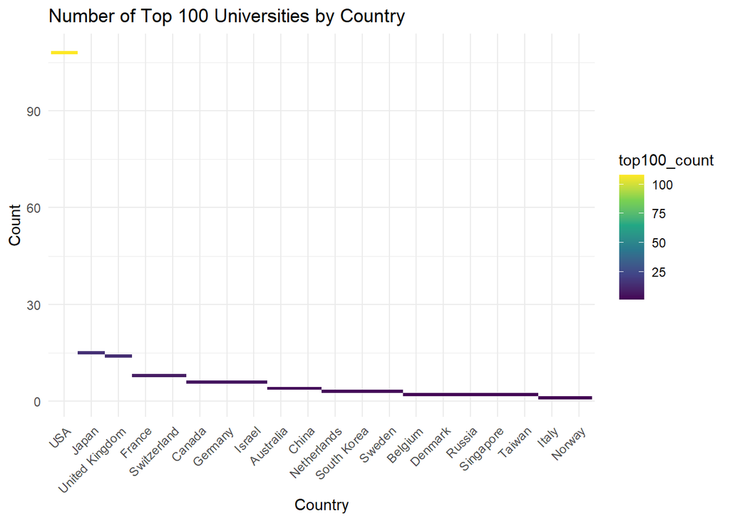

```r
if (all(c("country", "world_rank") %in% names(clean_data))) {
  library(reshape2)
  top100 <- clean_data %>% filter(world_rank <= 100)
  country_counts <- as.data.frame(table(top100$country))
  colnames(country_counts) <- c("country", "top100_count")
  ggplot(country_counts, aes(x = reorder(country, -top100_count), y = top100_count, fill = top100_count)) +
    geom_tile() +
    scale_fill_viridis_c() +
    labs(title = "Number of Top 100 Universities by Country", x = "Country", y = "Count") +
    theme_minimal() +
    theme(axis.text.x = element_text(angle = 45, hjust = 1))
}
```

```r
# If continent/region variable exists, facet by it
if ("continent" %in% names(clean_data) && all(c("score", "publications") %in% names(clean_data))) {
  ggplot(clean_data, aes(x = publications, y = score, color = continent)) +
    geom_point(alpha = 0.5) +
    geom_smooth(method = "lm", se = FALSE) +
    facet_wrap(~ continent) +
    scale_color_viridis_d() +
    labs(title = "Score vs. Publications by Continent", x = "Publications", y = "Score") +
    theme_minimal()
}
```

### Treemap: University Count by Country

```r
if (!requireNamespace("treemap", quietly = TRUE)) install.packages("treemap")
library(treemap)
if ("country" %in% names(clean_data)) {
  country_counts <- as.data.frame(table(clean_data$country))
  colnames(country_counts) <- c("country", "count")
  treemap(country_counts, index = "country", vSize = "count", title = "University Count by Country")
}
```

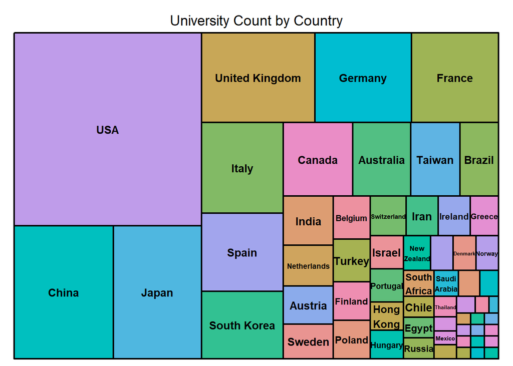